# Risk Factor Analysis

## Outcome Variable

**Outcome Variable:** ever_stunted

## Predictor Variables

**Intervention Variable:** cleanck

**Adjustment Set:**

- arm
- W_mage
- meducyrs
- feducyrs
- hhwealth_quart
- W_nrooms
- W_nhh
- W_nchldlt5
- W_parity
- trth2o
- impfloor
- delta_meducyrs
- delta_feducyrs
- delta_hhwealth_quart
- delta_W_nrooms
- delta_W_nhh
- delta_W_nchldlt5
- delta_W_parity
- delta_trth2o
- delta_impfloor

## Stratifying Variables

The analysis was stratified on these variable(s):

- agecat
- studyid
- country

## Data Summary

| agecat | studyid | country | cleanck | ever_stunted | n_cell | n |
| --- | --- | --- | --- | --- | --- | --- |
| 0-24 months (no birth st.) | ki0047075b-MAL-ED | PERU | 1 | 0 | 1 | 2 |
| 0-24 months (no birth st.) | ki0047075b-MAL-ED | PERU | 1 | 1 | 0 | 2 |
| 0-24 months (no birth st.) | ki0047075b-MAL-ED | PERU | 0 | 0 | 0 | 2 |
| 0-24 months (no birth st.) | ki0047075b-MAL-ED | PERU | 0 | 1 | 1 | 2 |
| 0-24 months (no birth st.) | ki0047075b-MAL-ED | SOUTH AFRICA | 1 | 0 | 0 | 1 |
| 0-24 months (no birth st.) | ki0047075b-MAL-ED | SOUTH AFRICA | 1 | 1 | 0 | 1 |
| 0-24 months (no birth st.) | ki0047075b-MAL-ED | SOUTH AFRICA | 0 | 0 | 1 | 1 |
| 0-24 months (no birth st.) | ki0047075b-MAL-ED | SOUTH AFRICA | 0 | 1 | 0 | 1 |
| 0-24 months (no birth st.) | ki1000108-CMC-V-BCS-2002 | INDIA | 1 | 0 | 21 | 296 |
| 0-24 months (no birth st.) | ki1000108-CMC-V-BCS-2002 | INDIA | 1 | 1 | 121 | 296 |
| 0-24 months (no birth st.) | ki1000108-CMC-V-BCS-2002 | INDIA | 0 | 0 | 7 | 296 |
| 0-24 months (no birth st.) | ki1000108-CMC-V-BCS-2002 | INDIA | 0 | 1 | 147 | 296 |
| 0-24 months (no birth st.) | ki1000108-IRC | INDIA | 1 | 0 | 94 | 352 |
| 0-24 months (no birth st.) | ki1000108-IRC | INDIA | 1 | 1 | 114 | 352 |
| 0-24 months (no birth st.) | ki1000108-IRC | INDIA | 0 | 0 | 49 | 352 |
| 0-24 months (no birth st.) | ki1000108-IRC | INDIA | 0 | 1 | 95 | 352 |
| 0-24 months (no birth st.) | ki1017093b-PROVIDE | BANGLADESH | 1 | 0 | 340 | 633 |
| 0-24 months (no birth st.) | ki1017093b-PROVIDE | BANGLADESH | 1 | 1 | 180 | 633 |
| 0-24 months (no birth st.) | ki1017093b-PROVIDE | BANGLADESH | 0 | 0 | 55 | 633 |
| 0-24 months (no birth st.) | ki1017093b-PROVIDE | BANGLADESH | 0 | 1 | 58 | 633 |
| 0-24 months (no birth st.) | ki1017093c-NIH-Crypto | BANGLADESH | 1 | 0 | 199 | 498 |
| 0-24 months (no birth st.) | ki1017093c-NIH-Crypto | BANGLADESH | 1 | 1 | 115 | 498 |
| 0-24 months (no birth st.) | ki1017093c-NIH-Crypto | BANGLADESH | 0 | 0 | 119 | 498 |
| 0-24 months (no birth st.) | ki1017093c-NIH-Crypto | BANGLADESH | 0 | 1 | 65 | 498 |
| 0-24 months (no birth st.) | ki1113344-GMS-Nepal | NEPAL | 1 | 0 | 8 | 517 |
| 0-24 months (no birth st.) | ki1113344-GMS-Nepal | NEPAL | 1 | 1 | 2 | 517 |
| 0-24 months (no birth st.) | ki1113344-GMS-Nepal | NEPAL | 0 | 0 | 215 | 517 |
| 0-24 months (no birth st.) | ki1113344-GMS-Nepal | NEPAL | 0 | 1 | 292 | 517 |
| 0-6 months (no birth st.) | ki0047075b-MAL-ED | PERU | 1 | 0 | 1 | 2 |
| 0-6 months (no birth st.) | ki0047075b-MAL-ED | PERU | 1 | 1 | 0 | 2 |
| 0-6 months (no birth st.) | ki0047075b-MAL-ED | PERU | 0 | 0 | 0 | 2 |
| 0-6 months (no birth st.) | ki0047075b-MAL-ED | PERU | 0 | 1 | 1 | 2 |
| 0-6 months (no birth st.) | ki0047075b-MAL-ED | SOUTH AFRICA | 1 | 0 | 0 | 1 |
| 0-6 months (no birth st.) | ki0047075b-MAL-ED | SOUTH AFRICA | 1 | 1 | 0 | 1 |
| 0-6 months (no birth st.) | ki0047075b-MAL-ED | SOUTH AFRICA | 0 | 0 | 1 | 1 |
| 0-6 months (no birth st.) | ki0047075b-MAL-ED | SOUTH AFRICA | 0 | 1 | 0 | 1 |
| 0-6 months (no birth st.) | ki1000108-CMC-V-BCS-2002 | INDIA | 1 | 0 | 96 | 292 |
| 0-6 months (no birth st.) | ki1000108-CMC-V-BCS-2002 | INDIA | 1 | 1 | 45 | 292 |
| 0-6 months (no birth st.) | ki1000108-CMC-V-BCS-2002 | INDIA | 0 | 0 | 84 | 292 |
| 0-6 months (no birth st.) | ki1000108-CMC-V-BCS-2002 | INDIA | 0 | 1 | 67 | 292 |
| 0-6 months (no birth st.) | ki1000108-IRC | INDIA | 1 | 0 | 143 | 352 |
| 0-6 months (no birth st.) | ki1000108-IRC | INDIA | 1 | 1 | 65 | 352 |
| 0-6 months (no birth st.) | ki1000108-IRC | INDIA | 0 | 0 | 87 | 352 |
| 0-6 months (no birth st.) | ki1000108-IRC | INDIA | 0 | 1 | 57 | 352 |
| 0-6 months (no birth st.) | ki1017093b-PROVIDE | BANGLADESH | 1 | 0 | 446 | 633 |
| 0-6 months (no birth st.) | ki1017093b-PROVIDE | BANGLADESH | 1 | 1 | 74 | 633 |
| 0-6 months (no birth st.) | ki1017093b-PROVIDE | BANGLADESH | 0 | 0 | 86 | 633 |
| 0-6 months (no birth st.) | ki1017093b-PROVIDE | BANGLADESH | 0 | 1 | 27 | 633 |
| 0-6 months (no birth st.) | ki1017093c-NIH-Crypto | BANGLADESH | 1 | 0 | 262 | 498 |
| 0-6 months (no birth st.) | ki1017093c-NIH-Crypto | BANGLADESH | 1 | 1 | 52 | 498 |
| 0-6 months (no birth st.) | ki1017093c-NIH-Crypto | BANGLADESH | 0 | 0 | 150 | 498 |
| 0-6 months (no birth st.) | ki1017093c-NIH-Crypto | BANGLADESH | 0 | 1 | 34 | 498 |
| 0-6 months (no birth st.) | ki1113344-GMS-Nepal | NEPAL | 1 | 0 | 10 | 517 |
| 0-6 months (no birth st.) | ki1113344-GMS-Nepal | NEPAL | 1 | 1 | 0 | 517 |
| 0-6 months (no birth st.) | ki1113344-GMS-Nepal | NEPAL | 0 | 0 | 416 | 517 |
| 0-6 months (no birth st.) | ki1113344-GMS-Nepal | NEPAL | 0 | 1 | 91 | 517 |
| 6-24 months | ki1000108-CMC-V-BCS-2002 | INDIA | 1 | 0 | 21 | 185 |
| 6-24 months | ki1000108-CMC-V-BCS-2002 | INDIA | 1 | 1 | 76 | 185 |
| 6-24 months | ki1000108-CMC-V-BCS-2002 | INDIA | 0 | 0 | 7 | 185 |
| 6-24 months | ki1000108-CMC-V-BCS-2002 | INDIA | 0 | 1 | 81 | 185 |
| 6-24 months | ki1000108-IRC | INDIA | 1 | 0 | 94 | 230 |
| 6-24 months | ki1000108-IRC | INDIA | 1 | 1 | 49 | 230 |
| 6-24 months | ki1000108-IRC | INDIA | 0 | 0 | 49 | 230 |
| 6-24 months | ki1000108-IRC | INDIA | 0 | 1 | 38 | 230 |
| 6-24 months | ki1017093b-PROVIDE | BANGLADESH | 1 | 0 | 284 | 456 |
| 6-24 months | ki1017093b-PROVIDE | BANGLADESH | 1 | 1 | 106 | 456 |
| 6-24 months | ki1017093b-PROVIDE | BANGLADESH | 0 | 0 | 35 | 456 |
| 6-24 months | ki1017093b-PROVIDE | BANGLADESH | 0 | 1 | 31 | 456 |
| 6-24 months | ki1017093c-NIH-Crypto | BANGLADESH | 1 | 0 | 185 | 397 |
| 6-24 months | ki1017093c-NIH-Crypto | BANGLADESH | 1 | 1 | 63 | 397 |
| 6-24 months | ki1017093c-NIH-Crypto | BANGLADESH | 0 | 0 | 118 | 397 |
| 6-24 months | ki1017093c-NIH-Crypto | BANGLADESH | 0 | 1 | 31 | 397 |
| 6-24 months | ki1113344-GMS-Nepal | NEPAL | 1 | 0 | 6 | 356 |
| 6-24 months | ki1113344-GMS-Nepal | NEPAL | 1 | 1 | 2 | 356 |
| 6-24 months | ki1113344-GMS-Nepal | NEPAL | 0 | 0 | 147 | 356 |
| 6-24 months | ki1113344-GMS-Nepal | NEPAL | 0 | 1 | 201 | 356 |

The following strata were considered:

- agecat: 0-24 months (no birth st.), studyid: ki0047075b-MAL-ED, country: PERU
- agecat: 0-24 months (no birth st.), studyid: ki0047075b-MAL-ED, country: SOUTH AFRICA
- agecat: 0-24 months (no birth st.), studyid: ki1000108-CMC-V-BCS-2002, country: INDIA
- agecat: 0-24 months (no birth st.), studyid: ki1000108-IRC, country: INDIA
- agecat: 0-24 months (no birth st.), studyid: ki1017093b-PROVIDE, country: BANGLADESH
- agecat: 0-24 months (no birth st.), studyid: ki1017093c-NIH-Crypto, country: BANGLADESH
- agecat: 0-24 months (no birth st.), studyid: ki1113344-GMS-Nepal, country: NEPAL
- agecat: 0-6 months (no birth st.), studyid: ki0047075b-MAL-ED, country: PERU
- agecat: 0-6 months (no birth st.), studyid: ki0047075b-MAL-ED, country: SOUTH AFRICA
- agecat: 0-6 months (no birth st.), studyid: ki1000108-CMC-V-BCS-2002, country: INDIA
- agecat: 0-6 months (no birth st.), studyid: ki1000108-IRC, country: INDIA
- agecat: 0-6 months (no birth st.), studyid: ki1017093b-PROVIDE, country: BANGLADESH
- agecat: 0-6 months (no birth st.), studyid: ki1017093c-NIH-Crypto, country: BANGLADESH
- agecat: 0-6 months (no birth st.), studyid: ki1113344-GMS-Nepal, country: NEPAL
- agecat: 6-24 months, studyid: ki1000108-CMC-V-BCS-2002, country: INDIA
- agecat: 6-24 months, studyid: ki1000108-IRC, country: INDIA
- agecat: 6-24 months, studyid: ki1017093b-PROVIDE, country: BANGLADESH
- agecat: 6-24 months, studyid: ki1017093c-NIH-Crypto, country: BANGLADESH
- agecat: 6-24 months, studyid: ki1113344-GMS-Nepal, country: NEPAL

### Dropped Strata

Some strata were dropped due to rare outcomes:

- agecat: 0-24 months (no birth st.), studyid: ki0047075b-MAL-ED, country: PERU
- agecat: 0-24 months (no birth st.), studyid: ki0047075b-MAL-ED, country: SOUTH AFRICA
- agecat: 0-24 months (no birth st.), studyid: ki1113344-GMS-Nepal, country: NEPAL
- agecat: 0-6 months (no birth st.), studyid: ki0047075b-MAL-ED, country: PERU
- agecat: 0-6 months (no birth st.), studyid: ki0047075b-MAL-ED, country: SOUTH AFRICA
- agecat: 0-6 months (no birth st.), studyid: ki1113344-GMS-Nepal, country: NEPAL
- agecat: 6-24 months, studyid: ki1113344-GMS-Nepal, country: NEPAL

## Methods Detail

We’re interested in the causal parameters $E[Y_a]$ for all values of $a \in \mathcal{A}$. These parameters represent the mean outcome if, possibly contrary to fact, we intervened to set all units to have $A=a$. Under the randomization and positivity assumptions, these are identified by the statistical parameters $\psi_a=E_W[E_{Y|A,W}(Y|A=a,W)]$. In addition, we’re interested in the mean of $Y$, $E[Y]$ under no intervention (the observed mean). We will estimate these parameters by using SuperLearner to fit the relevant likelihood factors – $E_{Y|A,W}(Y|A=a,W)$ and $p(A=a|W)$, and then updating our likelihood fit using a joint TMLE.

For unadjusted analyses ($W=\{\}$), initial likelihoods were estimated using Lrnr_glm to estimate the simple $E(Y|A)$ and Lrnr_mean to estimate $p(A)$. For adjusted analyses, a small library containing Lrnr_glmnet, Lrnr_xgboost, and Lrnr_mean was used.

Having estimated these parameters, we will then use the delta method to estimate relative risks and attributable risks relative to a prespecified baseline level of $A$.

# Results Detail

## Results Plots

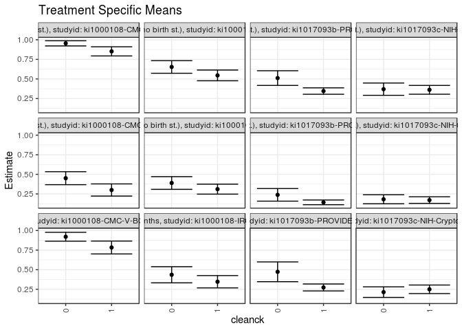

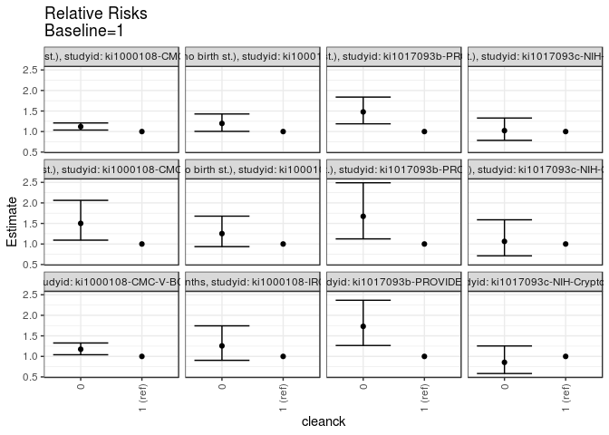

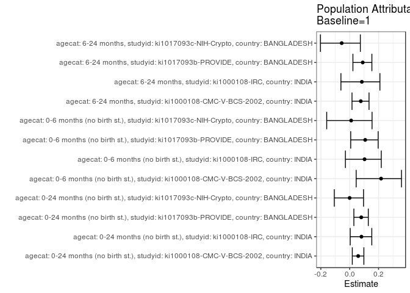

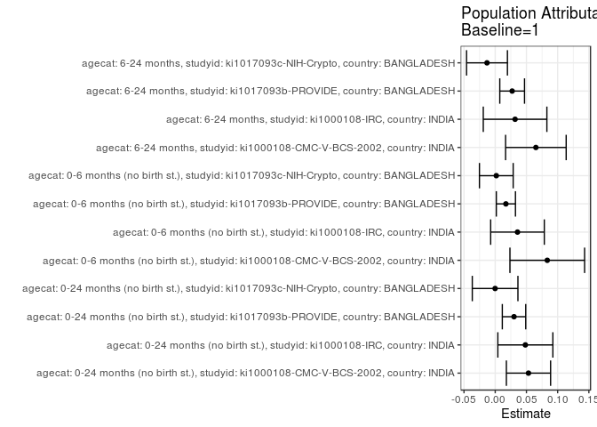

## Results Table

### Parameter: TSM

| agecat | studyid | country | intervention_level | baseline_level | estimate | ci_lower | ci_upper |
| --- | --- | --- | --- | --- | --- | --- | --- |
| 0-24 months (no birth st.) | ki1000108-CMC-V-BCS-2002 | INDIA | 1 | NA | 0.8521127 | 0.7936266 | 0.9105988 |
| 0-24 months (no birth st.) | ki1000108-CMC-V-BCS-2002 | INDIA | 0 | NA | 0.9545455 | 0.9215913 | 0.9874996 |
| 0-24 months (no birth st.) | ki1000108-IRC | INDIA | 1 | NA | 0.5454703 | 0.4770177 | 0.6139228 |
| 0-24 months (no birth st.) | ki1000108-IRC | INDIA | 0 | NA | 0.6532118 | 0.5726971 | 0.7337265 |
| 0-24 months (no birth st.) | ki1017093b-PROVIDE | BANGLADESH | 1 | NA | 0.3458662 | 0.3049134 | 0.3868190 |
| 0-24 months (no birth st.) | ki1017093b-PROVIDE | BANGLADESH | 0 | NA | 0.5113499 | 0.4177064 | 0.6049934 |
| 0-24 months (no birth st.) | ki1017093c-NIH-Crypto | BANGLADESH | 1 | NA | 0.3616231 | 0.3053915 | 0.4178547 |
| 0-24 months (no birth st.) | ki1017093c-NIH-Crypto | BANGLADESH | 0 | NA | 0.3697735 | 0.2913661 | 0.4481810 |
| 0-6 months (no birth st.) | ki1000108-CMC-V-BCS-2002 | INDIA | 1 | NA | 0.3001821 | 0.2225068 | 0.3778573 |
| 0-6 months (no birth st.) | ki1000108-CMC-V-BCS-2002 | INDIA | 0 | NA | 0.4507244 | 0.3680500 | 0.5333989 |
| 0-6 months (no birth st.) | ki1000108-IRC | INDIA | 1 | NA | 0.3109161 | 0.2472835 | 0.3745487 |
| 0-6 months (no birth st.) | ki1000108-IRC | INDIA | 0 | NA | 0.3895135 | 0.3085663 | 0.4704607 |
| 0-6 months (no birth st.) | ki1017093b-PROVIDE | BANGLADESH | 1 | NA | 0.1424672 | 0.1123278 | 0.1726066 |
| 0-6 months (no birth st.) | ki1017093b-PROVIDE | BANGLADESH | 0 | NA | 0.2383416 | 0.1580640 | 0.3186192 |
| 0-6 months (no birth st.) | ki1017093c-NIH-Crypto | BANGLADESH | 1 | NA | 0.1709427 | 0.1283968 | 0.2134887 |
| 0-6 months (no birth st.) | ki1017093c-NIH-Crypto | BANGLADESH | 0 | NA | 0.1816916 | 0.1242166 | 0.2391666 |
| 6-24 months | ki1000108-CMC-V-BCS-2002 | INDIA | 1 | NA | 0.7835052 | 0.7013218 | 0.8656885 |
| 6-24 months | ki1000108-CMC-V-BCS-2002 | INDIA | 0 | NA | 0.9204545 | 0.8637664 | 0.9771427 |
| 6-24 months | ki1000108-IRC | INDIA | 1 | NA | 0.3464484 | 0.2678815 | 0.4250152 |
| 6-24 months | ki1000108-IRC | INDIA | 0 | NA | 0.4352534 | 0.3323199 | 0.5381869 |
| 6-24 months | ki1017093b-PROVIDE | BANGLADESH | 1 | NA | 0.2733088 | 0.2289280 | 0.3176897 |
| 6-24 months | ki1017093b-PROVIDE | BANGLADESH | 0 | NA | 0.4731110 | 0.3469437 | 0.5992783 |
| 6-24 months | ki1017093c-NIH-Crypto | BANGLADESH | 1 | NA | 0.2499417 | 0.1951850 | 0.3046984 |
| 6-24 months | ki1017093c-NIH-Crypto | BANGLADESH | 0 | NA | 0.2138334 | 0.1463827 | 0.2812842 |

### Parameter: E(Y)

| agecat | studyid | country | intervention_level | baseline_level | estimate | ci_lower | ci_upper |
| --- | --- | --- | --- | --- | --- | --- | --- |
| 0-24 months (no birth st.) | ki1000108-CMC-V-BCS-2002 | INDIA | NA | NA | 0.9054054 | 0.8720096 | 0.9388012 |
| 0-24 months (no birth st.) | ki1000108-IRC | INDIA | NA | NA | 0.5937500 | 0.5423701 | 0.6451299 |
| 0-24 months (no birth st.) | ki1017093b-PROVIDE | BANGLADESH | NA | NA | 0.3759874 | 0.3382238 | 0.4137509 |
| 0-24 months (no birth st.) | ki1017093c-NIH-Crypto | BANGLADESH | NA | NA | 0.3614458 | 0.3192090 | 0.4036825 |
| 0-6 months (no birth st.) | ki1000108-CMC-V-BCS-2002 | INDIA | NA | NA | 0.3835616 | 0.3276935 | 0.4394298 |
| 0-6 months (no birth st.) | ki1000108-IRC | INDIA | NA | NA | 0.3465909 | 0.2968062 | 0.3963756 |
| 0-6 months (no birth st.) | ki1017093b-PROVIDE | BANGLADESH | NA | NA | 0.1595577 | 0.1310079 | 0.1881074 |
| 0-6 months (no birth st.) | ki1017093c-NIH-Crypto | BANGLADESH | NA | NA | 0.1726908 | 0.1394601 | 0.2059214 |
| 6-24 months | ki1000108-CMC-V-BCS-2002 | INDIA | NA | NA | 0.8486486 | 0.7968646 | 0.9004327 |
| 6-24 months | ki1000108-IRC | INDIA | NA | NA | 0.3782609 | 0.3154507 | 0.4410711 |
| 6-24 months | ki1017093b-PROVIDE | BANGLADESH | NA | NA | 0.3004386 | 0.2583143 | 0.3425629 |
| 6-24 months | ki1017093c-NIH-Crypto | BANGLADESH | NA | NA | 0.2367758 | 0.1949066 | 0.2786451 |

### Parameter: RR

| agecat | studyid | country | intervention_level | baseline_level | estimate | ci_lower | ci_upper |
| --- | --- | --- | --- | --- | --- | --- | --- |
| 0-24 months (no birth st.) | ki1000108-CMC-V-BCS-2002 | INDIA | 1 | 1 | 1.0000000 | 1.0000000 | 1.000000 |
| 0-24 months (no birth st.) | ki1000108-CMC-V-BCS-2002 | INDIA | 0 | 1 | 1.1202104 | 1.0373678 | 1.209669 |
| 0-24 months (no birth st.) | ki1000108-IRC | INDIA | 1 | 1 | 1.0000000 | 1.0000000 | 1.000000 |
| 0-24 months (no birth st.) | ki1000108-IRC | INDIA | 0 | 1 | 1.1975205 | 1.0043507 | 1.427843 |
| 0-24 months (no birth st.) | ki1017093b-PROVIDE | BANGLADESH | 1 | 1 | 1.0000000 | 1.0000000 | 1.000000 |
| 0-24 months (no birth st.) | ki1017093b-PROVIDE | BANGLADESH | 0 | 1 | 1.4784615 | 1.1886257 | 1.838971 |
| 0-24 months (no birth st.) | ki1017093c-NIH-Crypto | BANGLADESH | 1 | 1 | 1.0000000 | 1.0000000 | 1.000000 |
| 0-24 months (no birth st.) | ki1017093c-NIH-Crypto | BANGLADESH | 0 | 1 | 1.0225385 | 0.7863155 | 1.329727 |
| 0-6 months (no birth st.) | ki1000108-CMC-V-BCS-2002 | INDIA | 1 | 1 | 1.0000000 | 1.0000000 | 1.000000 |
| 0-6 months (no birth st.) | ki1000108-CMC-V-BCS-2002 | INDIA | 0 | 1 | 1.5015035 | 1.0932603 | 2.062192 |
| 0-6 months (no birth st.) | ki1000108-IRC | INDIA | 1 | 1 | 1.0000000 | 1.0000000 | 1.000000 |
| 0-6 months (no birth st.) | ki1000108-IRC | INDIA | 0 | 1 | 1.2527930 | 0.9357317 | 1.677287 |
| 0-6 months (no birth st.) | ki1017093b-PROVIDE | BANGLADESH | 1 | 1 | 1.0000000 | 1.0000000 | 1.000000 |
| 0-6 months (no birth st.) | ki1017093b-PROVIDE | BANGLADESH | 0 | 1 | 1.6729576 | 1.1240805 | 2.489846 |
| 0-6 months (no birth st.) | ki1017093c-NIH-Crypto | BANGLADESH | 1 | 1 | 1.0000000 | 1.0000000 | 1.000000 |
| 0-6 months (no birth st.) | ki1017093c-NIH-Crypto | BANGLADESH | 0 | 1 | 1.0628800 | 0.7111528 | 1.588567 |
| 6-24 months | ki1000108-CMC-V-BCS-2002 | INDIA | 1 | 1 | 1.0000000 | 1.0000000 | 1.000000 |
| 6-24 months | ki1000108-CMC-V-BCS-2002 | INDIA | 0 | 1 | 1.1747907 | 1.0402427 | 1.326741 |
| 6-24 months | ki1000108-IRC | INDIA | 1 | 1 | 1.0000000 | 1.0000000 | 1.000000 |
| 6-24 months | ki1000108-IRC | INDIA | 0 | 1 | 1.2563298 | 0.9048043 | 1.744427 |
| 6-24 months | ki1017093b-PROVIDE | BANGLADESH | 1 | 1 | 1.0000000 | 1.0000000 | 1.000000 |
| 6-24 months | ki1017093b-PROVIDE | BANGLADESH | 0 | 1 | 1.7310490 | 1.2661322 | 2.366681 |
| 6-24 months | ki1017093c-NIH-Crypto | BANGLADESH | 1 | 1 | 1.0000000 | 1.0000000 | 1.000000 |
| 6-24 months | ki1017093c-NIH-Crypto | BANGLADESH | 0 | 1 | 0.8555333 | 0.5837757 | 1.253799 |

### Parameter: PAR

| agecat | studyid | country | intervention_level | baseline_level | estimate | ci_lower | ci_upper |
| --- | --- | --- | --- | --- | --- | --- | --- |
| 0-24 months (no birth st.) | ki1000108-CMC-V-BCS-2002 | INDIA | 1 | NA | 0.0532927 | 0.0178815 | 0.0887039 |
| 0-24 months (no birth st.) | ki1000108-IRC | INDIA | 1 | NA | 0.0482797 | 0.0042174 | 0.0923420 |
| 0-24 months (no birth st.) | ki1017093b-PROVIDE | BANGLADESH | 1 | NA | 0.0301211 | 0.0113464 | 0.0488959 |
| 0-24 months (no birth st.) | ki1017093c-NIH-Crypto | BANGLADESH | 1 | NA | -0.0001773 | -0.0367314 | 0.0363767 |
| 0-6 months (no birth st.) | ki1000108-CMC-V-BCS-2002 | INDIA | 1 | NA | 0.0833796 | 0.0235831 | 0.1431760 |
| 0-6 months (no birth st.) | ki1000108-IRC | INDIA | 1 | NA | 0.0356748 | -0.0072760 | 0.0786256 |
| 0-6 months (no birth st.) | ki1017093b-PROVIDE | BANGLADESH | 1 | NA | 0.0170905 | 0.0017539 | 0.0324270 |
| 0-6 months (no birth st.) | ki1017093c-NIH-Crypto | BANGLADESH | 1 | NA | 0.0017480 | -0.0252757 | 0.0287718 |
| 6-24 months | ki1000108-CMC-V-BCS-2002 | INDIA | 1 | NA | 0.0651435 | 0.0166356 | 0.1136514 |
| 6-24 months | ki1000108-IRC | INDIA | 1 | NA | 0.0318125 | -0.0191258 | 0.0827509 |
| 6-24 months | ki1017093b-PROVIDE | BANGLADESH | 1 | NA | 0.0271297 | 0.0073175 | 0.0469420 |
| 6-24 months | ki1017093c-NIH-Crypto | BANGLADESH | 1 | NA | -0.0131659 | -0.0458958 | 0.0195640 |

### Parameter: PAF

| agecat | studyid | country | intervention_level | baseline_level | estimate | ci_lower | ci_upper |
| --- | --- | --- | --- | --- | --- | --- | --- |
| 0-24 months (no birth st.) | ki1000108-CMC-V-BCS-2002 | INDIA | 1 | NA | 0.0588606 | 0.0178699 | 0.0981405 |
| 0-24 months (no birth st.) | ki1000108-IRC | INDIA | 1 | NA | 0.0813132 | 0.0034875 | 0.1530609 |
| 0-24 months (no birth st.) | ki1017093b-PROVIDE | BANGLADESH | 1 | NA | 0.0801121 | 0.0287208 | 0.1287843 |
| 0-24 months (no birth st.) | ki1017093c-NIH-Crypto | BANGLADESH | 1 | NA | -0.0004905 | -0.1069107 | 0.0956982 |
| 0-6 months (no birth st.) | ki1000108-CMC-V-BCS-2002 | INDIA | 1 | NA | 0.2173824 | 0.0447854 | 0.3587931 |
| 0-6 months (no birth st.) | ki1000108-IRC | INDIA | 1 | NA | 0.1029306 | -0.0298850 | 0.2186181 |
| 0-6 months (no birth st.) | ki1017093b-PROVIDE | BANGLADESH | 1 | NA | 0.1071115 | 0.0069666 | 0.1971570 |
| 0-6 months (no birth st.) | ki1017093c-NIH-Crypto | BANGLADESH | 1 | NA | 0.0101223 | -0.1593948 | 0.1548539 |
| 6-24 months | ki1000108-CMC-V-BCS-2002 | INDIA | 1 | NA | 0.0767614 | 0.0159136 | 0.1338470 |
| 6-24 months | ki1000108-IRC | INDIA | 1 | NA | 0.0841021 | -0.0608767 | 0.2092681 |
| 6-24 months | ki1017093b-PROVIDE | BANGLADESH | 1 | NA | 0.0903005 | 0.0222100 | 0.1536493 |
| 6-24 months | ki1017093c-NIH-Crypto | BANGLADESH | 1 | NA | -0.0556048 | -0.2029823 | 0.0737174 |